# DATA6073ACODE

Esra Dogan,Samantha Mesa

2026-09-18

## Approach

What are the top three movies we would recommend to each user who hasn’t rated everything?

Introduction

In this assignment, we will build a “movie recommender” using the Global Baseline Estimate algorithm. The data comes from a survey where several people rated a set of movies, and most of them did not rate every movie.

Planned Approach

First we will read the movie ratings spreadsheet into R. The data has one row per user and one column per movie, with missing values where someone did not rate a film. We will reshape it into long format so that each row is one user–movie pair, which makes the calculations easier.

The idea behind the Global Baseline Estimate is simple. To recommend a movie to someone, we need to guess how much they would like the films they haven’t seen yet, so that we can rank those films and pick the best ones. The algorithm makes that guess by starting from the average rating across the whole survey and then adjusting it twice: once for how generous or harsh that particular user tends to be, and once for how well-liked that particular movie is overall. A user who rates everything highly gets an upward adjustment, and a movie that everyone enjoyed gets an upward adjustment too.

Anticipated Challenges

Some movies were rated by only a few people, so the numbers for those films may not be reliable.

We also need to be careful with the missing values. If we treat unrated movies as zeros instead of missing, the averages will come out wrong.

Finally, this method is not personalized, since it never looks at what kind of movies a person enjoys. We expect the users’ top three lists to look similar, and we want to discuss that in our conclusion.

## Code Base

```r
library(readr)
SummerMoviesRating <- read_csv("SummerMoviesRating.csv")
View(SummerMoviesRating)

ratings_long <- read.csv("SummerMoviesRating.csv", stringsAsFactors = FALSE)
names(ratings_long) <- tolower(trimws(names(ratings_long)))

# Drop any fully blank rows (e.g. stray blank lines in the source CSV)
ratings_long <- ratings_long[ratings_long$responder != "" &
                              !is.na(ratings_long$responder), ]

responders <- sort(unique(ratings_long$responder))
movies     <- sort(unique(ratings_long$movies))

data.frame(
  Responders        = length(responders),
  Movies            = length(movies),
  Ratings_collected = nrow(ratings_long),
  Possible_ratings  = length(responders) * length(movies)
)
```

```
##   Responders Movies Ratings_collected Possible_ratings
## 1         12     10                53              120
```

```r
ratings_matrix <- matrix(
  NA_real_,
  nrow = length(responders),
  ncol = length(movies),
  dimnames = list(responders, movies)
)

for (i in seq_len(nrow(ratings_long))) {
  ratings_matrix[ratings_long$responder[i], ratings_long$movies[i]] <-
    ratings_long$rating[i]
}

ratings_matrix
```

```
##          Dune Dune: Part 2 Michael Obsession Oppenheimer
## Person1    NA           NA       3         2          NA
## Person10    5            4      NA        NA          NA
## Person11    1           NA      NA        NA          NA
## Person12   NA           NA      NA        NA          NA
## Person2    NA           NA      NA         4          NA
## Person3    NA           NA       5         3          NA
## Person4    NA           NA       5         3          NA
## Person5    NA           NA       4         3          NA
## Person6    NA           NA      NA         5          NA
## Person7     1            2      NA        NA           4
## Person8    NA           NA      NA        NA           4
## Person9     3            5      NA        NA           5
##          Spider-Man: Brand New Day The Batman The Devil Wears Prada 2
## Person1                          4         NA                       2
## Person10                         2          1                      NA
## Person11                         5         NA                      NA
## Person12                         5         NA                      NA
## Person2                          5         NA                      NA
## Person3                          4         NA                       5
## Person4                          4         NA                       4
## Person5                          5         NA                       4
## Person6                          4         NA                      NA
## Person7                          4          2                      NA
## Person8                          4          3                      NA
## Person9                          5          4                      NA
##          The Odyssey Toy Story 5
## Person1            3           5
## Person10           4          NA
## Person11           5          NA
## Person12          NA          NA
## Person2            5          NA
## Person3            5           5
## Person4            4           3
## Person5            5           4
## Person6           NA          NA
## Person7            4          NA
## Person8           NA          NA
## Person9            5          NA
```

```r
overall_mean <- mean(ratings_matrix, na.rm = TRUE)

user_avg   <- rowMeans(ratings_matrix, na.rm = TRUE)
user_bias  <- user_avg - overall_mean

movie_avg  <- colMeans(ratings_matrix, na.rm = TRUE)
movie_bias <- movie_avg - overall_mean

# Baseline for every user/movie pair: mu + user_bias + movie_bias
baseline <- outer(user_bias, movie_bias, FUN = "+") + overall_mean
dimnames(baseline) <- dimnames(ratings_matrix)

# Ratings are on a 1-5 scale, so clip estimates to that range
baseline_clipped <- baseline
baseline_clipped[baseline_clipped > 5] <- 5
baseline_clipped[baseline_clipped < 1] <- 1

overall_mean
```

```
## [1] 3.849057
```

```r
sort(round(user_bias, 3), decreasing = TRUE)
```

```
## Person12  Person2  Person3  Person6  Person9  Person5  Person4 Person11
##    1.151    0.818    0.651    0.651    0.651    0.318   -0.016   -0.182
##  Person8 Person10  Person1  Person7
##   -0.182   -0.649   -0.682   -1.016
```

```r
sort(round(movie_bias, 3), decreasing = TRUE)
```

```
##               The Odyssey               Oppenheimer                   Michael
##                     0.595                     0.484                     0.401
## Spider-Man: Brand New Day               Toy Story 5   The Devil Wears Prada 2
##                     0.401                     0.401                    -0.099
##              Dune: Part 2                 Obsession                      Dune
##                    -0.182                    -0.516                    -1.349
##                The Batman
##                    -1.349
```

```r
round(baseline_clipped, 2)
```

```
##          Dune Dune: Part 2 Michael Obsession Oppenheimer
## Person1  1.82         2.98    3.57      2.65        3.65
## Person10 1.85         3.02    3.60      2.68        3.68
## Person11 2.32         3.48    4.07      3.15        4.15
## Person12 3.65         4.82    5.00      4.48        5.00
## Person2  3.32         4.48    5.00      4.15        5.00
## Person3  3.15         4.32    4.90      3.98        4.98
## Person4  2.48         3.65    4.23      3.32        4.32
## Person5  2.82         3.98    4.57      3.65        4.65
## Person6  3.15         4.32    4.90      3.98        4.98
## Person7  1.48         2.65    3.23      2.32        3.32
## Person8  2.32         3.48    4.07      3.15        4.15
## Person9  3.15         4.32    4.90      3.98        4.98
##          Spider-Man: Brand New Day The Batman The Devil Wears Prada 2
## Person1                       3.57       1.82                    3.07
## Person10                      3.60       1.85                    3.10
## Person11                      4.07       2.32                    3.57
## Person12                      5.00       3.65                    4.90
## Person2                       5.00       3.32                    4.57
## Person3                       4.90       3.15                    4.40
## Person4                       4.23       2.48                    3.73
## Person5                       4.57       2.82                    4.07
## Person6                       4.90       3.15                    4.40
## Person7                       3.23       1.48                    2.73
## Person8                       4.07       2.32                    3.57
## Person9                       4.90       3.15                    4.40
##          The Odyssey Toy Story 5
## Person1         3.76        3.57
## Person10        3.80        3.60
## Person11        4.26        4.07
## Person12        5.00        5.00
## Person2         5.00        5.00
## Person3         5.00        4.90
## Person4         4.43        4.23
## Person5         4.76        4.57
## Person6         5.00        4.90
## Person7         3.43        3.23
## Person8         4.26        4.07
## Person9         5.00        4.90
```

```r
top_n_recommendations <- function(user, mat, baseline_matrix, n = 3) {
  unrated <- names(which(is.na(mat[user, ])))
  if (length(unrated) == 0) return(NULL)
  preds <- sort(baseline_matrix[user, unrated], decreasing = TRUE)
  head(preds, n)
}

incomplete_users <- responders[apply(is.na(ratings_matrix), 1, any)]
complete_users   <- setdiff(responders, incomplete_users)

recommendation_table <- data.frame(
  User = character(0), Rank = integer(0),
  Movie = character(0), Predicted = numeric(0),
  stringsAsFactors = FALSE
)

for (u in incomplete_users) {
  recs <- top_n_recommendations(u, ratings_matrix, baseline_clipped, n = 3)
  for (k in seq_along(recs)) {
    recommendation_table <- rbind(
      recommendation_table,
      data.frame(User = u, Rank = k, Movie = names(recs)[k],
                 Predicted = round(unname(recs[k]), 3),
                 stringsAsFactors = FALSE)
    )
  }
}

recommendation_table
```

```
##        User Rank                   Movie Predicted
## 1   Person1    1             Oppenheimer     3.651
## 2   Person1    2            Dune: Part 2     2.984
## 3   Person1    3                    Dune     1.818
## 4  Person10    1             Oppenheimer     3.684
## 5  Person10    2                 Michael     3.601
## 6  Person10    3             Toy Story 5     3.601
## 7  Person11    1             Oppenheimer     4.151
## 8  Person11    2                 Michael     4.068
## 9  Person11    3             Toy Story 5     4.068
## 10 Person12    1                 Michael     5.000
## 11 Person12    2             Oppenheimer     5.000
## 12 Person12    3             The Odyssey     5.000
## 13  Person2    1                 Michael     5.000
## 14  Person2    2             Oppenheimer     5.000
```

[output cut: 22 more lines]

```r
knitr::kable(
  recommendation_table,
  col.names = c("User", "Rank", "Movie", "Predicted Rating"),
  caption = "Top 3 predicted movies for each user with unrated movies"
)
```

Top 3 predicted movies for each user with unrated movies

| User | Rank | Movie | Predicted Rating |
| --- | --- | --- | --- |
| Person1 | 1 | Oppenheimer | 3.651 |
| Person1 | 2 | Dune: Part 2 | 2.984 |
| Person1 | 3 | Dune | 1.818 |
| Person10 | 1 | Oppenheimer | 3.684 |
| Person10 | 2 | Michael | 3.601 |
| Person10 | 3 | Toy Story 5 | 3.601 |
| Person11 | 1 | Oppenheimer | 4.151 |
| Person11 | 2 | Michael | 4.068 |
| Person11 | 3 | Toy Story 5 | 4.068 |
| Person12 | 1 | Michael | 5.000 |
| Person12 | 2 | Oppenheimer | 5.000 |
| Person12 | 3 | The Odyssey | 5.000 |
| Person2 | 1 | Michael | 5.000 |
| Person2 | 2 | Oppenheimer | 5.000 |
| Person2 | 3 | Toy Story 5 | 5.000 |
| Person3 | 1 | Oppenheimer | 4.984 |
| Person3 | 2 | Dune: Part 2 | 4.318 |
| Person3 | 3 | Dune | 3.151 |
| Person4 | 1 | Oppenheimer | 4.318 |
| Person4 | 2 | Dune: Part 2 | 3.651 |
| Person4 | 3 | Dune | 2.484 |
| Person5 | 1 | Oppenheimer | 4.651 |
| Person5 | 2 | Dune: Part 2 | 3.984 |
| Person5 | 3 | Dune | 2.818 |
| Person6 | 1 | The Odyssey | 5.000 |
| Person6 | 2 | Oppenheimer | 4.984 |
| Person6 | 3 | Michael | 4.901 |
| Person7 | 1 | Michael | 3.234 |
| Person7 | 2 | Toy Story 5 | 3.234 |
| Person7 | 3 | The Devil Wears Prada 2 | 2.734 |
| Person8 | 1 | The Odyssey | 4.262 |
| Person8 | 2 | Michael | 4.068 |
| Person8 | 3 | Toy Story 5 | 4.068 |
| Person9 | 1 | Michael | 4.901 |
| Person9 | 2 | Toy Story 5 | 4.901 |
| Person9 | 3 | The Devil Wears Prada 2 | 4.401 |

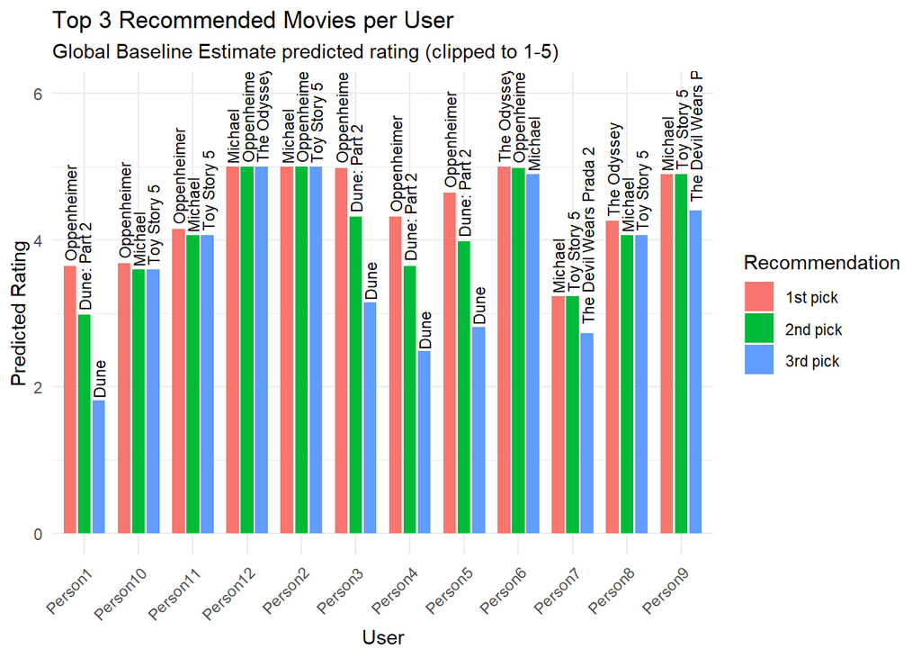

```r
library(ggplot2)

recommendation_table$Rank <- factor(
  recommendation_table$Rank,
  levels = c(1, 2, 3),
  labels = c("1st pick", "2nd pick", "3rd pick")
)

ggplot(recommendation_table,
       aes(x = User, y = Predicted, fill = Rank)) +
  geom_col(position = position_dodge(width = 0.8), width = 0.7) +
  geom_text(aes(label = Movie), position = position_dodge(width = 0.8),
            angle = 90, hjust = -0.05, size = 3) +
  coord_cartesian(ylim = c(0, 6)) +
  labs(title = "Top 3 Recommended Movies per User",
       subtitle = "Global Baseline Estimate predicted rating (clipped to 1-5)",
       x = "User", y = "Predicted Rating", fill = "Recommendation") +
  theme_minimal() +
  theme(axis.text.x = element_text(angle = 45, hjust = 1))
```

## So to answer our questions the three movie we would recommand are Toy Story 5, Oppenheimer and Michael